# tidy xgboost

```r
library(autostats)
library(workflows)
library(dplyr)
library(tune)
library(rsample)
library(hardhat)
```

`autostats` provides convenient wrappers for modeling, visualizing, and predicting using a tidy workflow. The emphasis is on rapid iteration and quick results using an intuitive interface based off the `tibble` and `tidy_formula`.

# Prepare data

Set up the iris data set for modeling. Create dummies and any new columns before making the formula. This way the same formula can be use throughout the modeling and prediction process.

```r
set.seed(34)

 iris %>%
  dplyr::as_tibble() %>%
  framecleaner::create_dummies(remove_first_dummy  = TRUE) -> iris1
```

```
#> 1 column(s) have become 2 dummy columns
```

```r
 iris1 %>%
 tidy_formula(target = Petal.Length) -> petal_form

 petal_form
```

```
#> Petal.Length ~ Sepal.Length + Sepal.Width + Petal.Width + Species_versicolor +
#>     Species_virginica
#> <environment: 0x7fb67b1e43a0>
```

Use the rsample package to split into train and validation sets.

```r
iris1 %>%
  rsample::initial_split() -> iris_split

iris_split %>%
  rsample::analysis() -> iris_train

iris_split %>%
  rsample::assessment() -> iris_val

iris_split
```

```
#> <Analysis/Assess/Total>
#> <112/38/150>
```

# Fit boosting models and visualize

Fit models to the training set using the formula to predict `Petal.Length`. Variable importance using gain for each `xgboost` model can be visualized.

## xgboost with bayesian hyperparameter optimization

```r
iris_train %>%
  auto_tune_xgboost(formula = petal_form, n_iter = 7L, tune_method = "bayes") -> xgb_tuned_bayes

xgb_tuned_bayes %>%
  parsnip::fit(iris_train) %>%
  hardhat::extract_fit_engine() -> xgb_tuned_fit_bayes

xgb_tuned_fit_bayes %>%
  visualize_model()
```

[output not shown]

## xgboost with grid search hyperparameter optimization

`xgboost` also can be tuned using a grid that is created internally using `dials::grid_max_entropy`. The `n_iter` parameter is passed to `grid_size`. Parallelization is highly effective in this method, so the default argument `parallel = TRUE` is recommended.

```r
iris_train %>%
  auto_tune_xgboost(formula = petal_form, n_iter = 5L,trees = 20L, loss_reduction = 2, mtry = .5, tune_method = "grid", parallel = FALSE) -> xgb_tuned_grid

xgb_tuned_grid %>%
  parsnip::fit(iris_train) %>%
  parsnip::extract_fit_engine() -> xgb_tuned_fit_grid

xgb_tuned_fit_grid %>%
  visualize_model()
```

[output not shown]

## xgboost with default parameters

```r
iris_train %>%
  tidy_xgboost(formula = petal_form) -> xgb_base
```

```
#> accuracy tested on a validation set
#> # A tibble: 3 × 4
#>   .metric .estimator .estimate target
#>   <chr>   <chr>          <dbl> <chr>
#> 1 ccc     standard       0.964 Petal.Length
#> 2 rmse    standard       0.375 Petal.Length
#> 3 rsq     standard       0.953 Petal.Length
```

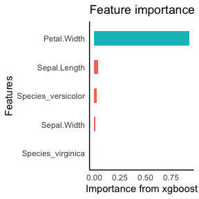

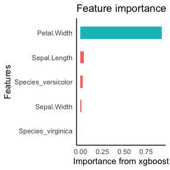

```r
xgb_base %>%
  visualize_model()
```

## xgboost with hand-picked parameters

```r
iris_train %>%
  tidy_xgboost(petal_form,
               trees = 250L,
               tree_depth = 3L,
               sample_size = .5,
               mtry = .5,
               min_n = 2) -> xgb_opt
```

```
#> accuracy tested on a validation set
#> # A tibble: 3 × 4
#>   .metric .estimator .estimate target
#>   <chr>   <chr>          <dbl> <chr>
#> 1 ccc     standard       0.955 Petal.Length
#> 2 rmse    standard       0.434 Petal.Length
#> 3 rsq     standard       0.960 Petal.Length
```

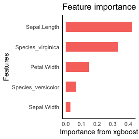

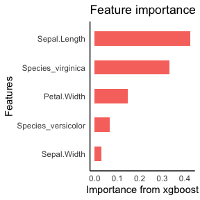

```r
xgb_opt %>%
  visualize_model()
```

## agtboost

automated gradient descent boosting with information-criterion heuristics that don’t need tuning

```r
iris_train %>%
  tidy_agtboost(petal_form) -> agtb
```

```
#> no dummies were created
```

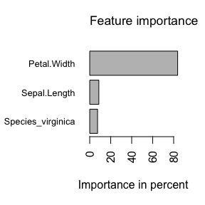

# predict on validation set

## make predictions

Predictions are iteratively added to the validation data frame. The name of the column is automatically created using the models name and the prediction target.

```r
xgb_base %>%
  tidy_predict(newdata = iris_val, form = petal_form) -> iris_val2
```

```
#> created the following column: Petal.Length_preds_xgb_base
```

```r
xgb_opt %>%
  tidy_predict(newdata = iris_val2, petal_form) -> iris_val3
```

```
#> created the following column: Petal.Length_preds_xgb_opt
```

```r
agtb %>%
    tidy_predict(newdata = iris_val3, petal_form)-> iris_val4

iris_val4 %>%
  names()
```

```
#> [1] "Sepal.Length"                "Sepal.Width"
#> [3] "Petal.Length"                "Petal.Width"
#> [5] "Species_versicolor"          "Species_virginica"
#> [7] "Petal.Length_preds_xgb_base" "Petal.Length_preds_xgb_opt"
#> [9] "Petal.Length_preds_agtb"
```

## predictions with eval_preds

Instead of evaluationg these prediction 1 by 1, This step is automated with `eval_preds`. This function is specifically designed to evaluate predicted columns with names given from `tidy_predict`.

```r
iris_val4 %>%
  eval_preds()
```

```
#> # A tibble: 9 × 5
#>   .metric .estimator .estimate model    target
#>   <chr>   <chr>          <dbl> <chr>    <chr>
#> 1 ccc     standard       0.957 agtb     Petal.Length
#> 2 ccc     standard       0.954 xgb_base Petal.Length
#> 3 ccc     standard       0.960 xgb_opt  Petal.Length
#> 4 rmse    standard       0.319 agtb     Petal.Length
#> 5 rmse    standard       0.352 xgb_base Petal.Length
#> 6 rmse    standard       0.299 xgb_opt  Petal.Length
#> 7 rsq     standard       0.975 agtb     Petal.Length
#> 8 rsq     standard       0.969 xgb_base Petal.Length
#> 9 rsq     standard       0.976 xgb_opt  Petal.Length
```

# get shapley values

`tidy_shap` has similar syntax to `tidy_predict` and can be used to get shapley values from `xgboost` models on a validation set.

```r
xgb_base %>%
  tidy_shap(newdata = iris_val, form = petal_form) -> shap_list
```

```r
shap_list$shap_tbl
```

```
#> # A tibble: 38 × 5
#>    Sepal.Length Sepal.Width Petal.Width Species_versicolor Species_virginica
#>           <dbl>       <dbl>       <dbl>              <dbl>             <dbl>
#>  1       -0.236     -0.0700       -1.97             0.0970          0.000452
#>  2       -0.284     -0.0764       -2.02             0.0954          0.000395
#>  3       -0.118     -0.0969       -2.04             0.0970          0.00137
#>  4       -0.244     -0.0778       -1.99             0.0970          0.000452
#>  5       -0.143     -0.0595       -2.08             0.0970          0.000452
#>  6       -0.281     -0.0627       -2.01             0.0970          0.000845
#>  7       -0.228     -0.0395       -1.90             0.0970          0.000856
#>  8       -0.260     -0.145        -2.04             0.0954          0.000351
#>  9       -0.223     -0.0909       -1.99             0.0954          0.000395
#> 10       -0.281      0.272        -1.86             0.0960         -0.00104
#> # … with 28 more rows
```

```r
shap_list$shap_summary
```

```
#> # A tibble: 5 × 5
#>   name                  cor       var     sum sum_abs
#>   <chr>               <dbl>     <dbl>   <dbl>   <dbl>
#> 1 Petal.Width         0.955 2.29       8.43    53.7
#> 2 Sepal.Length        0.809 0.0875    -2.27     7.82
#> 3 Species_versicolor -0.934 0.0333     3.33     7.20
#> 4 Sepal.Width        -0.696 0.0148     0.310    3.25
#> 5 Species_virginica  -0.326 0.0000230 -0.0427   0.107
```

[figure not shown]

```r
shap_list$swarmplot
```

```r
shap_list$scatterplots
```

[output not shown]

## understand xgboost with other functions from the original package

Overfittingin the base config may be related to growing deep trees.

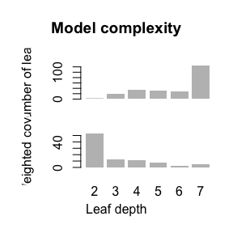

```r
 xgb_base %>%
  xgboost::xgb.plot.deepness()
```

[figure not shown]

```r
 xgb_base %>%
  xgboost::xgb.plot.deepness()
```

```r
xgb_base %>%
  xgboost::xgb.plot.tree(model = ., trees = 1)
```

[output not shown]